# Spectral representations of language are reflected in brain function

## Background

## A long history of research

Comprehension from reading, like hearing (@French1947), is fast and contextual.

## Semantic Patterns in the Brain

Does reading different sentences produce specific patterns of brain activity over time? Are these patterns repeatable and does their variability relate to semantic similarity? How do these sentence level patterns differ from word-level patterns?

## Spectral representations of language at the brain and sentence level

We show that functional activation of the left hemisphere language network reliably decodes an individual's reading experience. We use a framework based on dimensionality reduction ( *eigenanatomy* and *eigenwords* ) to identify brain sub-regions that differentiate related content during an extended session of sentence reading. A distinguishing feature of this framework is that it makes relatively few assumptions about the BOLD response beyond its slow (6 - 20+ second ) time-scale. Our statistical design focuses on the event occurrence (reading) and its quantitative representation. The BOLD response is encoded directly as event-matched spatiotemporal predictors from which we derive sparse dynamic, anatomical dictionary descriptors. Our approach seeks to address two of the fundamental issues at hand: (1) the need for a quantitative description of sentences that is related to sentence comprehension from reading and (2) a general formulation for relating the high-dimensional spatiotemporal BOLD space to spectral sentence representations.

## Overview

Below, we first describe the proposed sentence representation. We then describe BOLD preprocessing. Finally, we detail our approach to integrating these in a predictive model. We implement the analysis in `R` with `ANTsR` for imaging-specific tasks and SCCAN dimensionality reduction.

## Task Sentences

The sentence stimuli are presented randomly and with varying delays. Example sentences, with the total number of presentations, include:

```
## fspacenames
##            The.engineer.built.the.computer.
##                                          16
##              The.mouse.ran.into.the.forest.
##                                          18
##     The.minister.found.cash.at.the.airport.
##                                          17
## The.wealthy.family.celebrated.at.the.party.
##                                          17
##                          The.door.was.blue.
##                                          16
##              The.witness.went.to.the.trial.
##                                          16
##            The.couple.planned.the.vacation.
##                                          17
##                   The.artist.liked.chicken.
##                                          19
##           The.restaurant.was.loud.at.night.
##                                          17
##              The.bridge.survived.the.flood.
##                                          17
```

## Sentence transformation

In this work, we use *products or sums of eigenwords* as an eigensentence descriptor.

\[ e_s = \Pi_i e_i \text{ ... or ... } e_s = \frac{1}{n} \sum_{i=1}^{i=n} e_i \].

We have not yet carefully explored how these representations impact performance. Currently, we simply "choose one" and proceed.

## BOLD processing and priors

## BOLD signal characteristics

BOLD signal is information rich but noisy. We employ three fundamental aspects of BOLD to guide our preprocessing choices:

- Physiological noise contaminates the BOLD signal ( see compcor @Behzadi2007 )
- The BOLD response is slow ( > 5 seconds ) after a stimulus
- The response has limited temporal extent ( < 25 seconds )

## Processing decisions

Our processing therefore uses the following steps:

1. Assemble the BOLD blocks to match the overall event-related design file
   - optionally use anatomical labeling to select subregions for assembly
   - preliminary studies use language network regions: Frontal_Inf_Tri_L, Heschl_L, Temporal_Inf_L.
2. Learn physiological noise parameters from 1 block and apply them to the rest
3. Filter the fMRI with a Butterworth band-pass filter, extracting select mid-range frequencies
   - low frequency is 0.05
   - high frequency is 0.5
4. model sentence length effects (& motion—TODO) by linear regression

## Training & testing

Once these steps are complete we choose a training and testing split and perform statistical modeling.

## Multivariate statistical modeling

## Formulation

Convert the BOLD to a spatiotemporal representation. This model is of the form:

\[ Z_k = w + w_{00} x_{00} + w_{01} x_{01} + \cdots + w_{0p} x_{0p} + w_{10} x_{10} + \cdots + w_{tp} x_{tp} + \epsilon\]

where \(w\) represents a weighting term, \(Z_k\) represents a multivariate outcome (an *eigensentence*) at time k, \(x_{lm}\) represents a BOLD measurement at time \(l\) and space \(m\) and \(t\) represents the maximum temporal index within a short window near event \(Z_k\).

## Matrix formulation

So, if \(t=0\), then the global time index is \(k\); if \(t=1\), the global time index is \(k+1\), etcetera. This formulation allows us to simultaneously model and/or select variables in space-time. From here, we denote the right side of the above equation (for all \(k\)) as \(XW^T\) where \(X\) has dimensions \(n \times p\) and \(W\) has dimensions \(k \times p\). Similarly, \(Z\) is a matrix of *eigensentence* representations with dimension \(n \times q\).

## Sparse canonical correlation between space-time BOLD and eigenwords

CCA maximizes \(PearsonCorrelation( XW^T, ZY^T )\) where \(X, W\) are as above and \(Z\) and \(Y\) are similarly defined. CCA optimizes the matrices \(W, Y\) operating on \(X, Z\) to find a low-dimensional representation of the data pair \(( X , Z )\) in which correlation is maximal. Following ideas outlined in @Dhillon2014 and @Avants2014, this method can be extended with sparsity constraints that yield rows of \(W, Y\) with a controllable number of non-zero entries.

## Predictive model

Given CCA solution matrix \(W\), one may employ the low-dimensional representation, \(XW^T\), in multi-label classification. Currently, we employ SVM or random forests as multi-label learners for the problem:

\[L_i = f( XW^T ),\]

that is, learning a (sentence) label function from the BOLD data.

## Results

## Decoding targets

We decode all 240 sentences. Preliminarily, we find SVD-SVM SVM-PredErr: 4.345703125 %, vs random 0.416666666666667 % and CCA-SVM results CCA-PredErr: 7.32421875 %, vs random 0.416666666666667 %. The SVD-SVM uses the SVD of the matrix \(X\) as predictors.

A simple example [link](http://htmlpreview.github.io/?https://github.com/stnava/RKRNS/blob/doc/src/eigBrainLang.html) shows the misclassification network ( see the interactive graph ). Every sentence is represented by 2 nodes, the truth and the prediction. These 2 nodes have the same color. Under perfect classification, only these node pairs will be connected with a thick edge. The edge weights are proportional to the number of classification cases. You can zoom and click on the graph to get an idea of what sentences are well-classified.

## Temporal dynamics

A "HRF" is estimated by CCA.

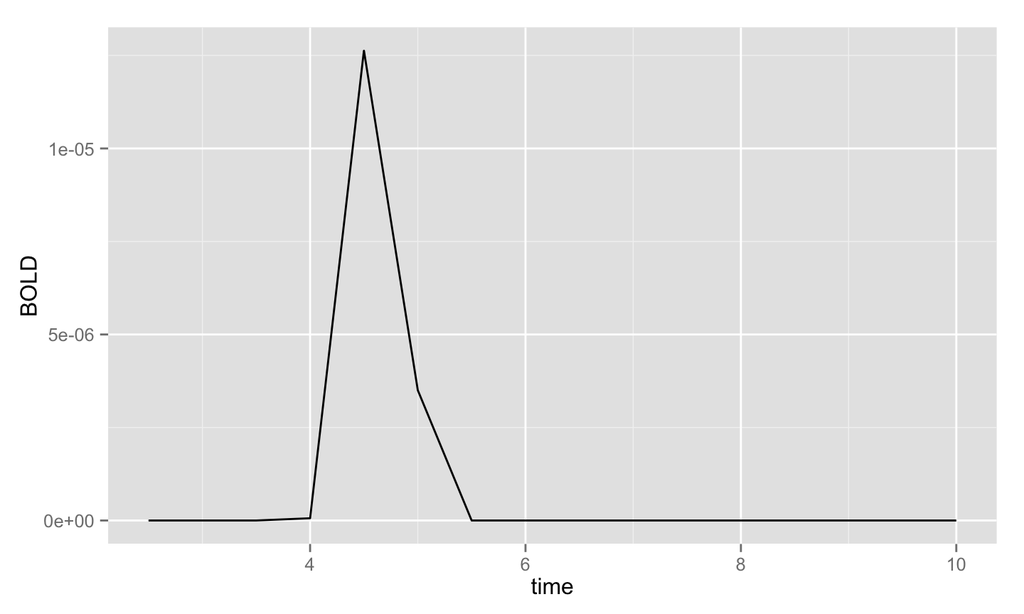

```r
mydata <- data.frame(time=c(1:length(myestimatedhrf))*TR+eventshift*TR,BOLD=myestimatedhrf)
ggplot(mydata,aes(time,BOLD))+geom_line()
```

##

This function sometimes has an appearance that is similar to what's expected from the literature. It is estimated by converting a row of \(W\) back to matrix representation and inspecting the variability in weights over time. Something similar may be done to find the corresponding anatomical function.

## Anatomical locality

Sparse CCA selects voxels from within the language network to maximize predictive accuracy. Where are these voxels? This work is yet to be done carefully. Preliminary investigations (and our use of spatiotemporally regularized SCCAN @Avants2014) show that the voxels are locally clustered and distributed across inferior temporal lobe, superior temporal (Heschl's?) gyrus and inferior frontal gyrus.

## Discussion

## Problems

There are several problems and shortcomings to this analysis.

- Eigenwords are somewhat arbitrary and may not reflect neural organization of semantic meaning
- Optimization of parameters was performed on one subject's dataset though we strived to make minimal assumptions
- Interpretability is not optimal
- Visualization needs improvement, especially of brain activity over time
- No explicit modeling of the residual BOLD signal due to prior events